# ggalignment

Afton Coombs

2025-02-23

## Introduction

The `ggalignment` package does one thing – it plot D&D-style alignment charts. If you’re unfamiliar, this is what they look like:

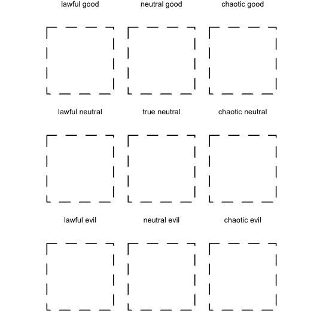

```r
library(ggalignment)
library(dplyr)

ggalignment(alignment = data.frame(img = character(),
                                   alignment = character()),
            font_size = 3)
```

Typically, each box contains an image of a person or thing. Each element of the chart should have a value in the x direction that represents how lawful or chaotic they are, and a value in the y direction that represents how good or evil they are. In this example, I’ve used some images of my cats and my perception of their alignments.

## Simple Plotting Alignment

To plot one image per box, you only need to pass in a `data.frame` containing two columns, `img` and `alignment`, which represent respectively the image path and the alignment name. For example:

```r
align_cats <- example_cats()
```

If you pass this to the `ggalignment()` function, it will plot each of these images in the center of each box.

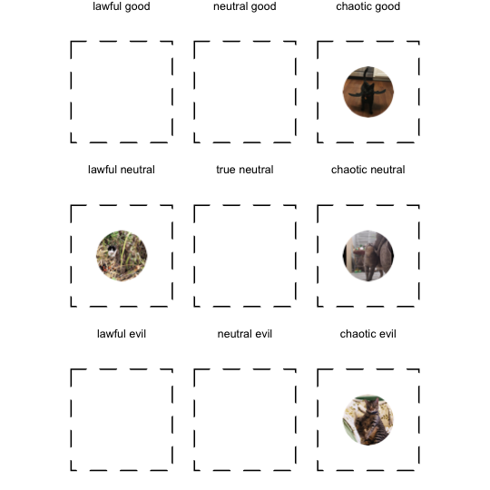

```r
ggalignment(align_cats, font_size = 3)
```

You can also provide images of different shapes (not just circles) and these will likewise center on the origin or use the `x` and `y` columns if provided.

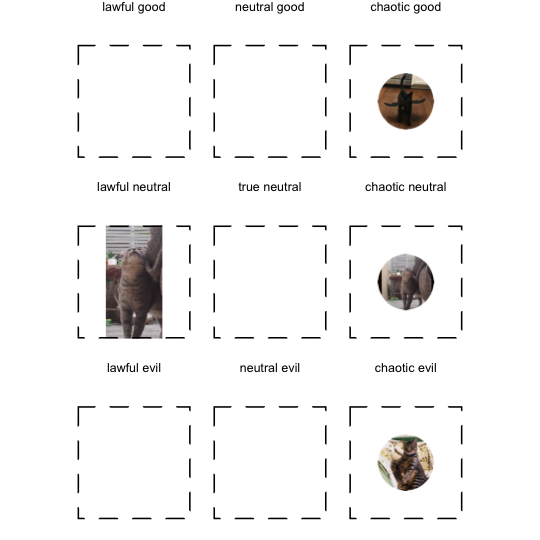

```r
cats_rect <-
  align_cats %>%
  mutate(img = c(align_cats$img[1:3],
                 system.file("img/gray_2.png", package = "ggalignment")))

ggalignment(alignment = cats_rect, font_size = 3)
```

## Plotting Alignment with Coordinates

If you have more than one image per alignment box, or if you would just like further control over the placement of the image in the box, you can also provide columns `x` and `y` in your `alignment` data passed to `ggalignment()` which will specify the x and y coordinates for each image.

Within each box, the coordinate system extends from -1 to 1 in both axes, and is centered at the origin. We can modify the default plot by providing `x` and `y` columns.

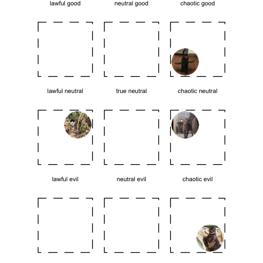

```r
cats_with_coords <-
  align_cats %>%
  mutate(x = c(0.5, -0.5, -0.5, 0.5),
                y = c(-0.5, -0.5, 0.5, 0.5))

ggalignment(alignment = cats_with_coords, font_size = 3)
```

This also works if there are multiple images per box, and `x` and `y` columns are required in this case to prevent two images occupying the same space at the origin and masking each other.

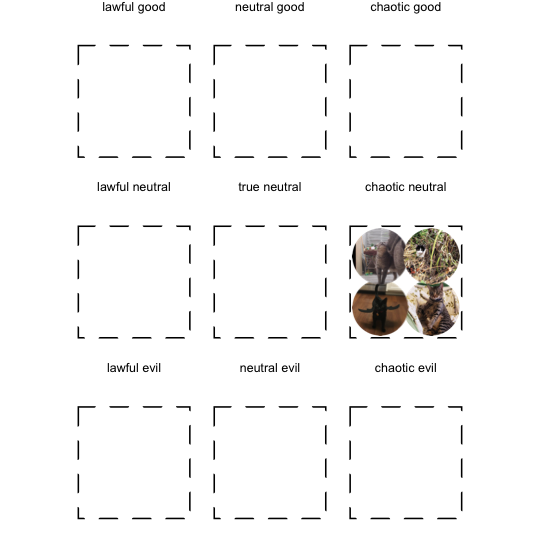

```r
cats_with_multi_image <-
  align_cats %>%
  mutate(alignment = rep("chaotic neutral")) %>%
  mutate(x = c(0.5, -0.5, -0.5, 0.5),
                y = c(-0.5, -0.5, 0.5, 0.5))

ggalignment(alignment = cats_with_multi_image,
            font_size = 3)
```

## Controlling Image Size

These two parameters allow you to adjust the image size. For example, if I use `max_images_per_dim = 1` with the default setting of `max_image_dim = "width"`, I will get an image that is the full width of the facet box.

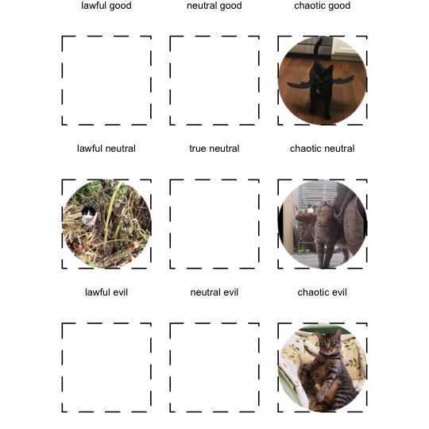

```r
ggalignment(alignment = align_cats,
            font_size = 3,
            max_images_per_dim = 1)
```

Setting `max_images_per_dim = 2` will cause the images to take up 1/2 the width of the facet box.

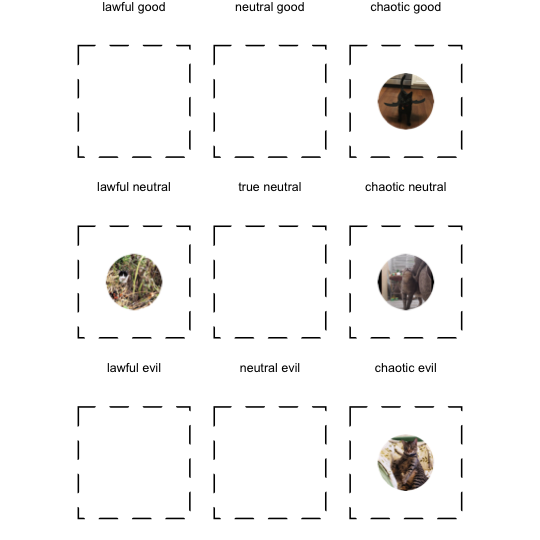

```r
ggalignment(alignment = align_cats,
            font_size = 3,
            max_images_per_dim = 2)
```

Likewise, `max_images_per_dim = 4` will yield images that are 1/4 the width of the facet box. Controlling the image size is useful if you have a lot of images in a single box, and the default of `max_images_per_dim = 2` will lead to overcrowding.

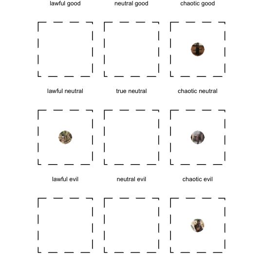

```r
ggalignment(alignment = align_cats,
            font_size = 3,
            max_images_per_dim = 4)
```

## Customizing the Look

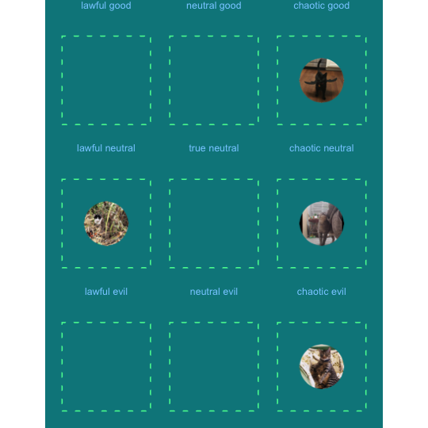

```r
ggalignment(alignment = align_cats,
            line_type = "dotted",
            line_color = "seagreen1",
            background_color = "turquoise4",
            font_color = "skyblue1",
            font_size = 3)
```

## Using Your Own Files

If you want to use your own image files, just construct a data.frame containing an `img` column containing the file paths, an `alignment` column containing the alignments, and optionally `x` and `y` columns determining the location of each image within its alignment facet. If you have multiple images in a single alignment, `x` and `y` are required.

First, let’s look at an example with local files. We’ll use the R logo and a portrait of my cat Oberon (thank you to artist ChargedAsylum for the portrait!).

[figure not shown]

```r
local_example <-
  data.frame(img = c("r_logo.png",
                     "obie_portrait.png"),
             alignment = c("lawful good",
                           "chaotic neutral"))

ggalignment(local_example, font_size = 3)
```

You can also use a URL as your image path.

[figure not shown]

```r
url_example <-
  data.frame(img = c("https://www.r-project.org/Rlogo.png",
                     "https://avatars.githubusercontent.com/u/18043377?v=4"),
             alignment = c("lawful good",
                           "chaotic neutral"))

try({ # wrapped with a try block here to prevent CRAN issues
  ggalignment(url_example, font_size = 3)
 })
```